# Most damaging events in terms of human and economic damage.

luiyusen97

7/22/2020

# Abstract

This short analysis finds out the overall most damaging events in terms of population and economic damage, in order to best focus preventive measures.

## Data Processing

Data was downloaded from the links in the url vector. The first URL is the one containing the raw data. No initial transformations were made.

```r
# loading packages
library(tidyverse)
```

```r
# file downloading DATA PROCESSING
url <- c("https://d396qusza40orc.cloudfront.net/repdata%2Fdata%2FStormData.csv.bz2",
         "https://d396qusza40orc.cloudfront.net/repdata%2Fpeer2_doc%2Fpd01016005curr.pdf",
         "https://d396qusza40orc.cloudfront.net/repdata%2Fpeer2_doc%2FNCDC%20Storm%20Events-FAQ%20Page.pdf")
if (!file.exists("rawdata.csv.bz2")){
    download.file(url = url[1],
                  destfile = "rawdata.csv.bz2")
}
if (!file.exists("rawdata_doc.pdf")){
    download.file(url = url[2],
                  destfile = "rawdata_doc.doc")
}
if (!file.exists("rawdata_faq.pdf")){
    download.file(url = url[3],
                  destfile = "rawdata_faq.pdf")
}

#read data
stormdata <- read.csv("rawdata.csv.bz2")
```

## Population damage

Population damage was taken from the FATALITIES and INJURIES columns of the raw data. Sums were taken of both damage types of each event type. Negligible event types are those that have overall caused very low population damage in terms of fatalities and injuries. The cut-off point of 1000 was enough to narrow the list of most damaging events down to 14. Figure 1 below shows the 14 most damaging event types.

```r
# harmful wrt population hp FATALITIES/INJURIES

# Calculate the sums of fatalities and injuries for each event type
stormdata_orderedevtype <- group_by(stormdata, EVTYPE, .drop = FALSE)
sum_fatalities <- summarise(stormdata_orderedevtype, sum_fat = sum(FATALITIES))
sum_injuries <- summarise(stormdata_orderedevtype, sum_inj = sum(INJURIES))
```

[figure not shown]

```r
sum_popdmg <- merge(sum_fatalities, sum_injuries, by = "EVTYPE")

# Remove data entries with negligible values to narrow down selection of event
# to the most damaging
empty_indices <- vector(mode = "numeric")
for (i in 1:nrow(sum_popdmg)){
    if ((sum_popdmg[i, 2] < 1000) & (sum_popdmg[i, 3] < 1000)){
        empty_indices <- c(empty_indices, i)
    }
}
sum_popdmg <- sum_popdmg[-empty_indices, ]
sum_popdmg <- mutate(sum_popdmg, eventtype = 1:nrow(sum_popdmg))

# find the maximum values for fatalities and injuries, and their corresponding
# event type
max_fat <- sum_popdmg[which(sum_popdmg$sum_fat==max(sum_popdmg$sum_fat)), ]
max_inj <- sum_popdmg[which(sum_popdmg$sum_inj==max(sum_popdmg$sum_inj)), ]

# plot the most damaging events in different colours, and circle the largest
# values for fatalities and injuries
sum_popdmg_plot <- ggplot(sum_popdmg) +
    geom_point(mapping = aes(x = eventtype, y = sum_fat, colour = "red")) +
    geom_point(mapping = aes(x = eventtype, y = sum_inj, colour = "blue")) +
    geom_point(shape = 1, mapping = aes(x = max_fat[ , 4], y = max_fat[ , 2])) +
    geom_point(shape = 1, mapping = aes(x = max_inj[ , 4], y = max_inj[ , 3])) +
    labs(title = "Figure 1: Fatalities and Injuries by event type",
         x = "Event type", y = "Fatalities/Injuries") +
    scale_color_manual(labels = c("Fatalities", "Injuries"),
                       values = c("red", "cadetblue3"))
print(sum_popdmg_plot)
```

## Property and crop damage

The property and crop damage were multiplied by 10 to the power of exponents. These exponents were retrieved from the property and crop damage exponent columns. Then, the values for each event type are summed up. The plots show the top 10 for both property and crop damage values.

```r
# economic damage
# calculate the sums of property and economic damage for each event type
for (i in nrow(stormdata_orderedevtype)){
    if (stormdata_orderedevtype[i, "PROPDMGEXP"] %in% letters){
        print(stormdata_orderedevtype[i, "PROPDMGEXP"])
        stormdata_orderedevtype[i, "PROPDMGEXP"] <- toupper(stormdata_orderedevtype[i, "PROPDMGEXP"])
    }
}

# convert the PROPDMGEXP column to numeric
convert_to_exponent <- function(exponent_chr){
    exponentials_numeric <- as.character(1:9)
    exponentials_string <- c(" ", "H", "K", rep(" ", 2), "M", rep(" ", 2), "B")
    if (exponent_chr[[1]] %in% exponentials_numeric){
        exponent <- which(exponentials_numeric == exponent_chr[[1]])
    } else if (exponent_chr[[1]] %in% LETTERS){
        exponent <- which(exponentials_string == exponent_chr[[1]])
    } else {
        exponent <- 0L
    }
    return(exponent)
}
# multiply the property and crop damage columns by 10^exponents
stormdata_orderedevtype <- mutate(stormdata_orderedevtype, PROPDMGEXP = convert_to_exponent(PROPDMGEXP))
stormdata_orderedevtype <- mutate(stormdata_orderedevtype, PROPDMG = PROPDMG * (10^PROPDMGEXP))
stormdata_orderedevtype <- mutate(stormdata_orderedevtype, CROPDMGEXP = convert_to_exponent(CROPDMGEXP))
stormdata_orderedevtype <- mutate(stormdata_orderedevtype, CROPDMG = CROPDMG * (10^CROPDMGEXP))

sum_propdmg <- summarise(stormdata_orderedevtype, sum_propdmg = sum(PROPDMG))
sum_cropdmg <- summarise(stormdata_orderedevtype, sum_cropdmg = sum(CROPDMG))
```

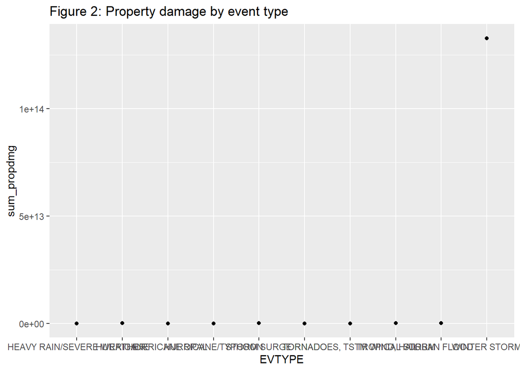

```r
sum_econdmg <- merge(sum_propdmg, sum_cropdmg, by = "EVTYPE")

# remove values that are negligible. Keep the most damaging events
empty_indices <- vector(mode = "numeric")
for (i in 1:nrow(sum_econdmg)){
    if ((sum_econdmg[i, 2] < 400000) & (sum_econdmg[i, 3] < 400000)){
        empty_indices <- c(empty_indices, i)
    }
}
sum_econdmg <- sum_econdmg[-empty_indices, ]

sum_econdmg <- mutate(sum_econdmg, eventtype = 1:nrow(sum_econdmg))

# find the greatest damage values for both property and crop damage
max_propdmg <- sum_econdmg[which(sum_econdmg$sum_propdmg==max(sum_econdmg$sum_propdmg)), ]
max_cropdmg <- sum_econdmg[which(sum_econdmg$sum_cropdmg==max(sum_econdmg$sum_cropdmg)), ]

sum_propdmg <- arrange(sum_econdmg, desc(sum_propdmg))[1:10, -3]
sum_propdmg_plot <- ggplot(sum_propdmg, mapping = aes(EVTYPE, sum_propdmg)) +
    geom_point() + ggtitle("Figure 2: Property damage by event type")
print(sum_propdmg_plot)
```

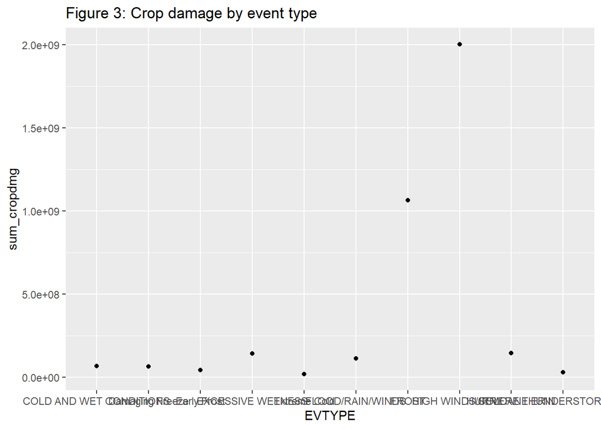

```r
sum_cropdmg <- arrange(sum_econdmg, desc(sum_cropdmg))[1:10, -2]
sum_cropdmg_plot <- ggplot(sum_cropdmg, mapping = aes(EVTYPE, sum_cropdmg)) +
    geom_point() + ggtitle("Figure 3: Crop damage by event type")
print(sum_cropdmg_plot)
```

## Results

For population damage, the most harmful in terms of fatalities and injuries is:

```r
print(max_fat)
```

```
##     EVTYPE sum_fat sum_inj eventtype
## 12 TORNADO    5633   91346        12
```

For property damage, the most harmful is:

```r
print(max_propdmg)
```

```
##           EVTYPE  sum_propdmg sum_cropdmg eventtype
## 118 WINTER STORM 1.327206e+14     1978.99       118
```

And for crop damage, the most harmful is:

```r
print(max_cropdmg)
```

```
##             EVTYPE sum_propdmg sum_cropdmg eventtype
## 58 HIGH WINDS/COLD     6.1e+08   2.005e+09        58
```